# survival_analysis

## PROJECT - USE OF SURVIVAL ANALYSIS IN TELECOM CHURN DATASET

## What is Survival Analysis ?

Survival analysis is a branch of statistics for analyzing the expected duration of time until one or more events happen, such as death in biological organisms and failure in mechanical systems. Survival analysis attempts to answer questions such as: what is the proportion of a population which will survive past a certain time? Of those that survive, at what rate will they die or fail? Can multiple causes of death or failure be taken into account? How do particular circumstances or characteristics increase or decrease the probability of survival?

## Exploratory Data Analysis

### Load and Read the Dataset

Before we load the dataset, we will set up our environment by importing necessary libraries.

```python
#Disable warnings in Anaconda
import warnings
warnings.filterwarnings('ignore')

#Visualization libraries
import matplotlib.pyplot as plt
import seaborn as sns
sns.set()

#Graphics in SVG format are more sharp and legible
%config InlineBackend.figure_format = 'svg'

#Increase the default plot size and set the color scheme
plt.rcParams['figure.figsize'] = (8,5)
#This works as well - plt.rcParams['figure.figsize'] = 8,5
plt.rcParams['image.cmap'] = 'viridis'

import pandas as pd
import numpy as np
```

- Now, let's load the dataset that we will put into the `DataFrame`.
- We have [Telco Customer Churn dataset](https://www.kaggle.com/blastchar/telco-customer-churn/data#WA_Fn-UseC_-Telco-Customer-Churn.csv). The dataset includes information about:
  > - Customers who left within the last month – the column is called Churn
  > - Services that each customer has signed up for – phone, multiple lines, internet, online security, online backup, device protection, tech support, and streaming TV and movies
  > - Customer account information – how long they’ve been a customer, contract, payment method, paperless billing, monthly charges, and total charges
  > - Demographic info about customers – gender, age range, and if they have partners and dependents

```python
# Load the dataset
df = pd.read_csv('data/telecom.csv')
```

```python
# Printing the shape of the dataframe
df.shape
```

```
(7043, 21)
```

```python
# Displaying first 5 records of the dataframe
df.head()
```

|  | customerID | gender | SeniorCitizen | Partner | Dependents | tenure | PhoneService | MultipleLines | InternetService | OnlineSecurity | ... | DeviceProtection | TechSupport | StreamingTV | StreamingMovies | Contract | PaperlessBilling | PaymentMethod | MonthlyCharges | TotalCharges | Churn |
| --- | --- | --- | --- | --- | --- | --- | --- | --- | --- | --- | --- | --- | --- | --- | --- | --- | --- | --- | --- | --- | --- |
| 0 | 7590-VHVEG | Female | 0 | Yes | No | 1 | No | No phone service | DSL | No | ... | No | No | No | No | Month-to-month | Yes | Electronic check | 29.85 | 29.85 | No |
| 1 | 5575-GNVDE | Male | 0 | No | No | 34 | Yes | No | DSL | Yes | ... | Yes | No | No | No | One year | No | Mailed check | 56.95 | 1889.5 | No |
| 2 | 3668-QPYBK | Male | 0 | No | No | 2 | Yes | No | DSL | Yes | ... | No | No | No | No | Month-to-month | Yes | Mailed check | 53.85 | 108.15 | Yes |
| 3 | 7795-CFOCW | Male | 0 | No | No | 45 | No | No phone service | DSL | Yes | ... | Yes | Yes | No | No | One year | No | Bank transfer (automatic) | 42.30 | 1840.75 | No |
| 4 | 9237-HQITU | Female | 0 | No | No | 2 | Yes | No | Fiber optic | No | ... | No | No | No | No | Month-to-month | Yes | Electronic check | 70.70 | 151.65 | Yes |

5 rows × 21 columns

```python
df.info()
```

```
<class 'pandas.core.frame.DataFrame'>
RangeIndex: 7043 entries, 0 to 7042
Data columns (total 21 columns):
customerID          7043 non-null object
gender              7043 non-null object
SeniorCitizen       7043 non-null int64
Partner             7043 non-null object
Dependents          7043 non-null object
tenure              7043 non-null int64
PhoneService        7043 non-null object
MultipleLines       7043 non-null object
InternetService     7043 non-null object
OnlineSecurity      7043 non-null object
OnlineBackup        7043 non-null object
DeviceProtection    7043 non-null object
TechSupport         7043 non-null object
StreamingTV         7043 non-null object
StreamingMovies     7043 non-null object
Contract            7043 non-null object
PaperlessBilling    7043 non-null object
PaymentMethod       7043 non-null object
MonthlyCharges      7043 non-null float64
TotalCharges        7043 non-null object
Churn               7043 non-null object
dtypes: float64(1), int64(2), object(18)
memory usage: 1.1+ MB
```

- We can convert the categorical features having 'Yes' and 'No' observations into 0 and 1.
- Also, `TotalCharges` is of object datatype which can be converted to numeric as well.

```python
df['Partner'] =  df['Partner'].map({'Yes':1 , 'No':0})
df['Dependents'] = df['Dependents'].map({'Yes':1 , 'No':0})
df['PhoneService'] = df['PhoneService'].map({'Yes':1 , 'No':0})
df['PaperlessBilling'] = df['PaperlessBilling'].map({'Yes':1 , 'No':0})
df['Churn'] = df['Churn'].map({'Yes':1 , 'No':0})
df['TotalCharges'] = df['TotalCharges'].convert_objects(convert_numeric=True)
```

```python
# Verifying the above implementation
df.info()
```

```
<class 'pandas.core.frame.DataFrame'>
RangeIndex: 7043 entries, 0 to 7042
Data columns (total 21 columns):
customerID          7043 non-null object
gender              7043 non-null object
SeniorCitizen       7043 non-null int64
Partner             7043 non-null int64
Dependents          7043 non-null int64
tenure              7043 non-null int64
PhoneService        7043 non-null int64
MultipleLines       7043 non-null object
InternetService     7043 non-null object
OnlineSecurity      7043 non-null object
OnlineBackup        7043 non-null object
DeviceProtection    7043 non-null object
TechSupport         7043 non-null object
StreamingTV         7043 non-null object
StreamingMovies     7043 non-null object
Contract            7043 non-null object
PaperlessBilling    7043 non-null int64
PaymentMethod       7043 non-null object
MonthlyCharges      7043 non-null float64
TotalCharges        7032 non-null float64
Churn               7043 non-null int64
dtypes: float64(2), int64(7), object(12)
memory usage: 1.1+ MB
```

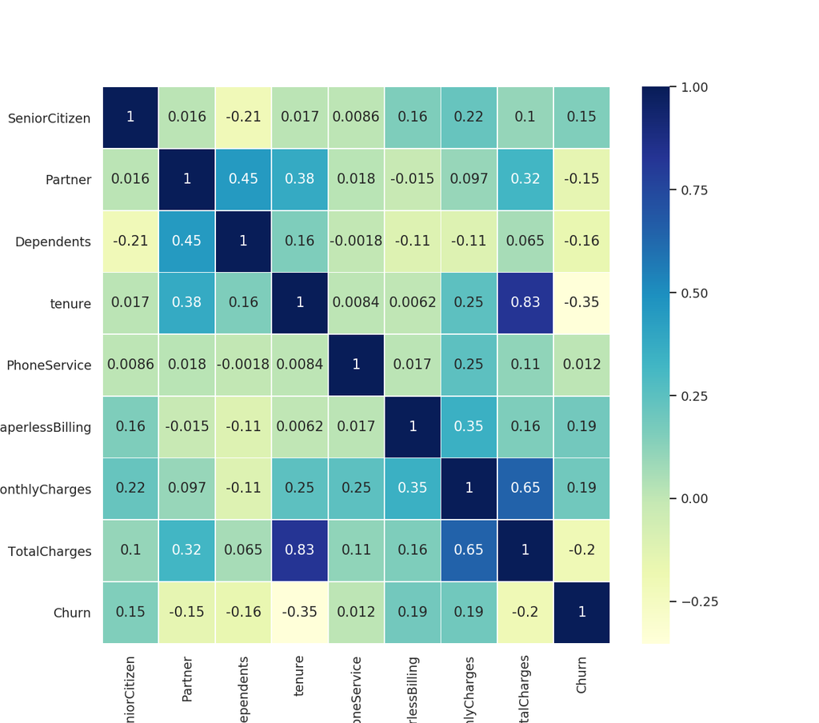

```python
# Plotting Heatmap
%matplotlib notebook
sns.heatmap(df.corr(), annot = True, linewidths=.5, cmap="YlGnBu");
```

As we can see changing the datatype of `TotalCharges` has resulted in some null values. We can replace the null values with the mean.

```python
# Impute the null values with mean
df.TotalCharges.fillna(value=df['TotalCharges'].mean(),inplace=True)
```

```python
# Compute the statistics for 'tenure' feature which is in 'months'
df.tenure.describe()
```

```
count    7043.000000
mean       32.371149
std        24.559481
min         0.000000
25%         9.000000
50%        29.000000
75%        55.000000
max        72.000000
Name: tenure, dtype: float64
```

```python
# Visualizing the above

from plotly.offline import download_plotlyjs, init_notebook_mode, plot, iplot
import plotly
import plotly.graph_objs as go

init_notebook_mode(connected=True)


#Create boxplot for the 'tenure' feature(s)

trace0 = go.Box(
            y = df['tenure'],
            name = 'Tenure'
            )

#Define the data array
data = [trace0]
#Set the title
layout = {'title': 'Box plot for Tenure feature'}


#Create a 'Figure' and plot it
fig = go.Figure(data = data, layout = layout)
iplot(fig, show_link=False)
```

[interactive chart not shown]

## Estimating the survival function

We will be looking at the customer retention period when estimating the survival function. The duration factor is given by `tenure` feature and `Churn` is the event as far as this dataset is concerned.

### Kaplan–Meier estimator

- Most commonly used method for survial analysis
- Non-parametric statistic used to estimate the survival function from lifetime data.

```python
from lifelines import KaplanMeierFitter
```

First, we will plot an overall Kaplan-Meier estimate and it's confidence intervals without the involvment of any cohorts.

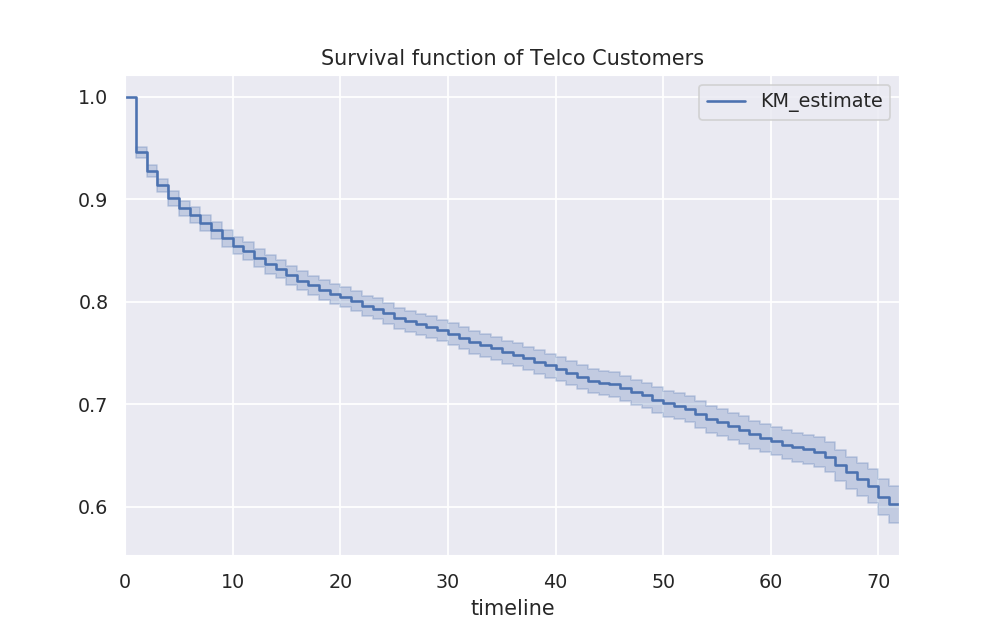

```python
%matplotlib notebook
k = KaplanMeierFitter()

# Specify the duration factor
D = df['tenure']
# Specify the event
E = df['Churn']

# Fit the data into the model
k.fit(D, event_observed = E)

# Plot the survival function
k.plot()
plt.title('Survival function of Telco Customers');
```

The y-axis represents the customer retention period after 't' months which is plotted on the x-axis.

Now we will estimate the survival function using KM technique involving cohorts. First, we will segment based on `MultipleLines` followed by `Contract`.

```python
df['MultipleLines'].value_counts()
```

```
No                  3390
Yes                 2971
No phone service     682
Name: MultipleLines, dtype: int64
```

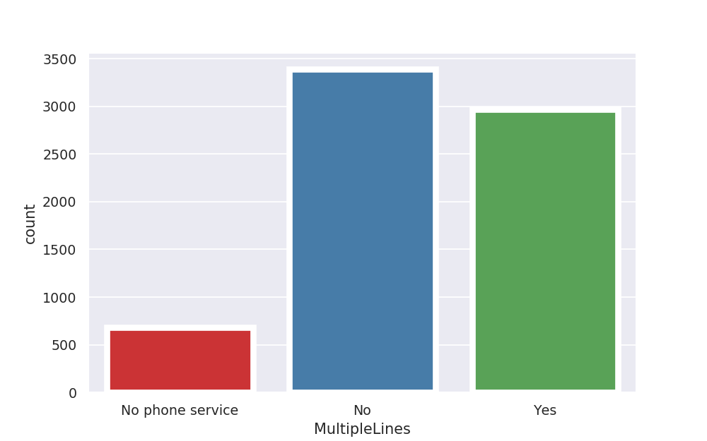

```python
%matplotlib notebook
plt.rcParams['figure.figsize'] = (8,5)
sns.countplot(x = 'MultipleLines', data = df, color = 'Green, Red', linewidth = 5, palette = "Set1");
```

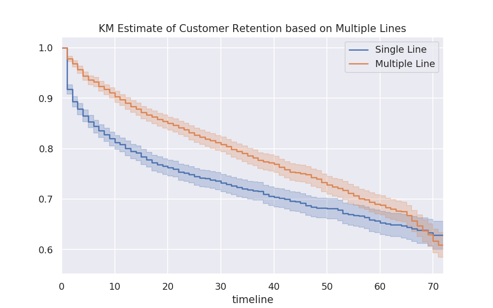

```python
%matplotlib notebook
kmf = KaplanMeierFitter()

# Customers having single line
SL = (df['MultipleLines'] == 'No')
# Customer having multiple lines
ML = (df['MultipleLines'] == 'Yes')

# Fit the model
kmf.fit(D[SL], event_observed=E[SL], label='Single Line')
a1 = kmf.plot()
# Fit the model
kmf.fit(D[ML], event_observed=E[ML], label='Multiple Line')
kmf.plot(ax=a1);

plt.title("KM Estimate of Customer Retention based on Multiple Lines");
```

```python
df['Contract'].value_counts()
```

```
Month-to-month    3875
Two year          1695
One year          1473
Name: Contract, dtype: int64
```

```python
%matplotlib notebook
plt.rcParams['figure.figsize'] = (8,5)
sns.countplot(x = 'Contract', data = df, color = 'Green, Red', linewidth = 5, palette = "Set1");
```

[output not shown]

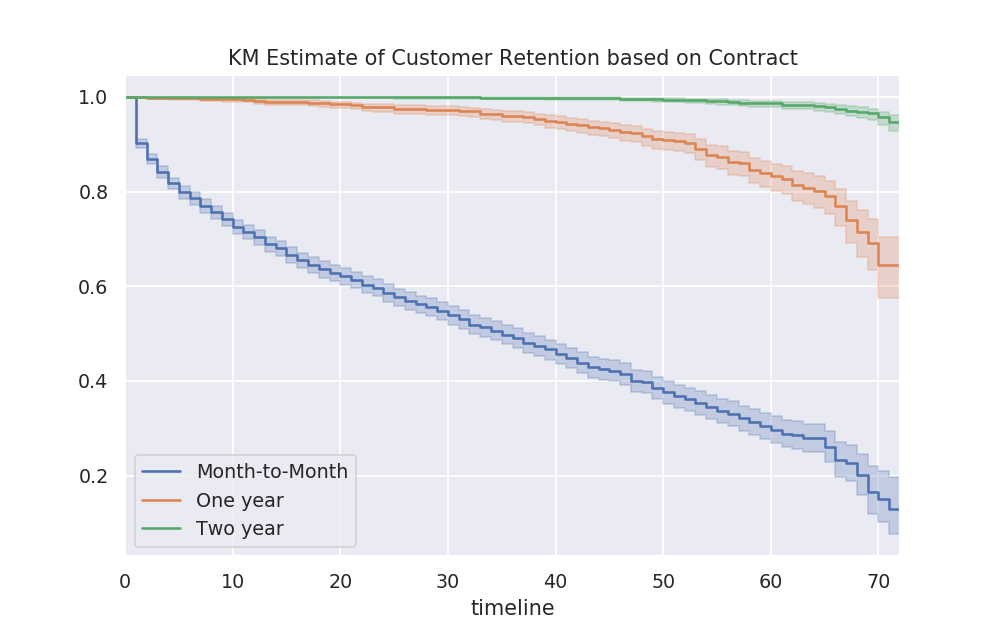

```python
%matplotlib notebook
kmf1 = KaplanMeierFitter()

# Customers having monthly contract
m1 = (df['Contract'] == 'Month-to-month')
# Customers having yearly contract
m2 = (df['Contract'] == 'One year')
# Customers having bi-yearly contract
m3 = (df['Contract'] == 'Two year')

# Fit the model
kmf1.fit(D[m1], E[m1], label='Month-to-Month')
ax = kmf1.plot()

# Fit the model
kmf1.fit(D[m2], E[m2], label='One year')
ax1 = kmf1.plot(ax=ax)

# Fit the model
kmf1.fit(D[m3], E[m3], label='Two year')
kmf1.plot(ax=ax1);

plt.title("KM Estimate of Customer Retention based on Contract");
```

**Observation**

- It is quite evident from the above plot that customers with monthly plan are the ones who have the fastest churn rate. On the other hand, telco users with two years plan have the highest retention period.
- Unlike `MultipleLines` segment, the KM curve based on `Contract` does follow the constant proportionality assumption(as the curves aren't overlapping each other and as well as maintaing a constant distance for most part of the plot).

### Logrank Test

- Hypothesis test to compare the survival distributions of two samples
- We will apply this test on the `MultipleLines` segment.

```python
from lifelines.statistics import logrank_test
```

```python
'''
SL -> Customers having single line
SL = (df['MultipleLines'] == 'No')

ML -> Customer having multiple lines
ML = (df['MultipleLines'] == 'Yes')

alpha -> confidence level
'''

results = logrank_test(D[ML], D[SL], E[ML], E[SL], alpha=0.99 )

# Printing the summary
results.print_summary()
```

```
<lifelines.StatisticalResult>
               t_0 = -1
 null_distribution = chi squared
degrees_of_freedom = 1
             alpha = 0.99

---
 test_statistic      p  -log2(p)
          31.26 <0.005     25.40
```

```python
Z = results.test_statistic

# Number of events observed
total_events = E.sum()

hazard_ratio = np.exp(Z*np.sqrt(4/total_events))
print(hazard_ratio)
```

```
4.247270127542291
```

**Conclusion**

## Estimating hazard rates

### Nelson-Aalen estimator

The survival functions is a great way to summarize and visualize the survival dataset, however it is not the only way. If we are curious about the hazard function h(t) of a population, we unfortunately cannot transform the Kaplan Meier estimate as the statistics doesn't work quite that well.  
Fortunately, there is a proper non-parametric estimator of the cumulative hazard function known as Nelson-Aalen estimator.

First, we will plot an overall Nelson-Aalen estimate without the involvment of any cohorts.

```python
from lifelines import NelsonAalenFitter

naf = NelsonAalenFitter()

# Fit the data into the model
naf.fit(D,event_observed=E)
```

```
<lifelines.NelsonAalenFitter: fitted with 7043 total observations, 5174 right-censored observations>
```

```
          NA_estimate
timeline
0.0          0.000000
1.0          0.055550
2.0          0.074896
3.0          0.090219
4.0          0.104193
```

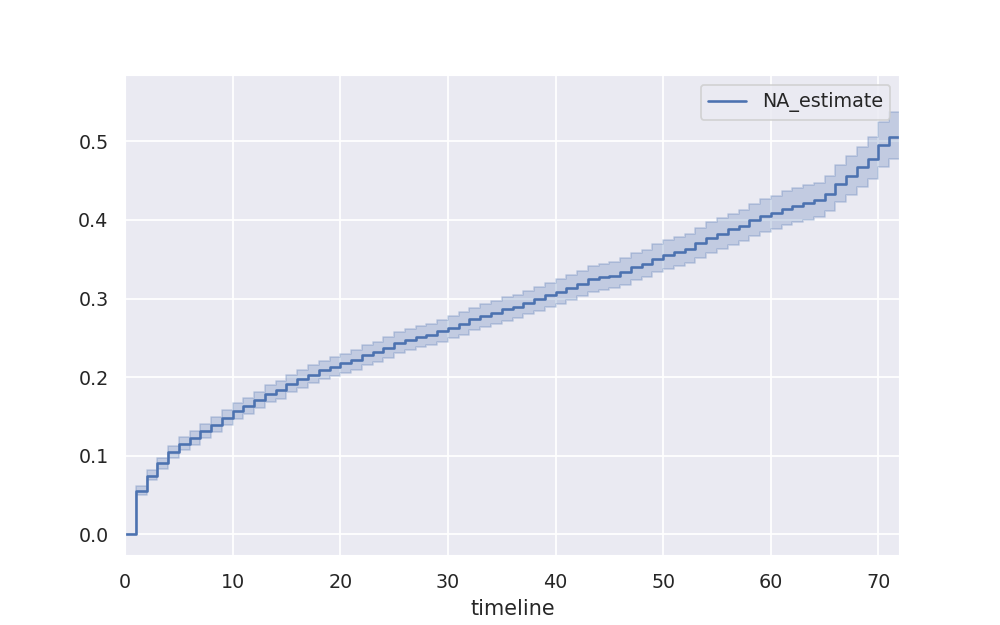

```python
%matplotlib notebook

print(naf.cumulative_hazard_.head())

#Plot the estimate
naf.plot();
```

**Observation**

- We can infer from the above plot that hazard starts off high and gets smaller(as seen by the decreasing rate of change).

Now, we will plot this estimate curve by `Contract` feature during the first `60` months.

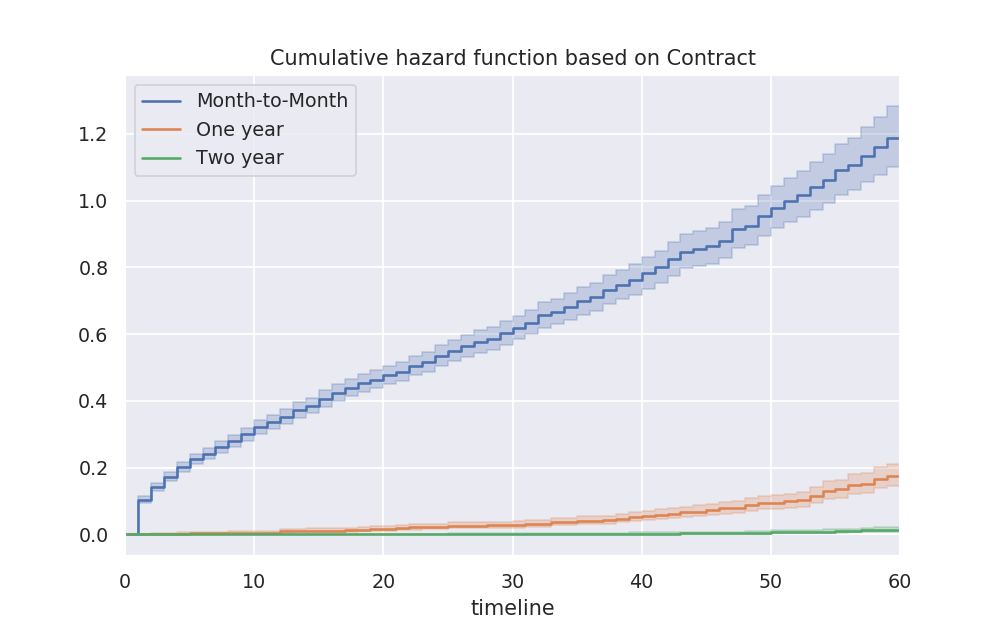

```python
%matplotlib notebook

'''
Customers having monthly contract
m1 = (df['Contract'] == 'Month-to-month')

Customers having yearly contract
m2 = (df['Contract'] == 'One year')

Customers having bi-yearly contract
m3 = (df['Contract'] == 'Two year')

'''
naf.fit(D[m1], event_observed=E[m1], label="Month-to-Month")
ax = naf.plot(loc=slice(0, 60))

naf.fit(D[m2], event_observed=E[m2], label="One year")
ax1 = naf.plot(ax=ax, loc=slice(0, 60))

naf.fit(D[m3], event_observed=E[m3], label="Two year")
naf.plot(ax=ax1, loc=slice(0, 60))

plt.title("Cumulative hazard function based on Contract");
```

## Reference

1. https://lifelines.readthedocs.io/en/latest/index.html
2. https://en.wikipedia.org/wiki/Survival_analysis